# Working paper

FONDECYT N° 1171072 “Justicia, legitimidad y cambio social en el ámbito laboral”

por Valentina Andrade

13 enero, 2021

# 1 Introducción

En el siguiente documento es un borrador para el trabajo con la base de datos longitudinal `ELSOC`. Para ello se trabajará con los siguientes documentos que se enlistan según función:

## 1.1 Hipótesis

- Paper Gerber, Moya, Castillo, Orchard and Puga (2020) [“Acting collectively againts injustice”](https://osf.io/ng8tf/)
- Fichas realizadas sobre teorías de la acción colectiva (eg. Klandermans, Cohen, Watts, Olson) para verificar si existen hipótesis generativas y/o temporales.

## 1.2 Metodología

- Manual de usuario de ELSOC
- Bases de datos ELSOC
- Libro de códigos ELSOC
- Actualizar lecturas sobre panel data
  - Andreß et al (2013) Applied Panel Data Analysis for Economic and Social Surveys
  - Smith and Fuertes (2017) Panel Time-Series
  - Sigmund and Ferstl (2019) Panel Vector Autoregression in R with the package panelvar
  - Agregar uno temático como el de Fitzenberger et. al (1999) Wer ist noch Mitglied in Gewerkschaften? Eine Panelanalyse für Westdeutschland

# 2 Artículos

## 2.1 Acting collectively againts injustice

### 2.1.1 Objetivo

Analizar las percepciones de injusticia en eltrato y la legitimidad de las autoridades con el fin de identificar un mecanismo que aienta las acciones por fuera de las normas del sistema y que tienden a involucrar accion violenta.

### 2.1.2 Hipótesis

**General**: Las personas se sienten más dispuestas a movilizarse cuando perciben que una situación es injusta (percepción injusticia), se sienten capaces de generar un cambio (percepción de eficacia) y se identifican con otras personas de un mismo grupo identidad social). Se prueba en acciones colectivas normativas y acciones colectivas no-normativas

**Específicas**: Se basan en injusticia en el trato que las personas perciben respecto a las autoridades

#### 2.1.2.1 A. Directas

- $H_1$. Una mayor percepción de injusticia en el trato de las autoridades, menor será la percepción de legitimidad de de autoridades
- $H_2a$. Una mayor legitimación de las autoridades, por su parte, se debiera asociar a una menor justificación de la acción colectiva no-normativa
- $H_2b$. (…) A una mayor normativa (two-sides)
- $H_3a$. La percepción de injusticia en el trato tendrá efectos directos positivos en la justificación de la acción colectiva no-normativa.
- $H_3b$. y normativa (one side?)

#### 2.1.2.2 B. Indirectas

- $H_4a$. A mayor percepción de injusticia en el trato, menor legitimación en autoridades y eso aumenta acción colectiva no normativa. (med positivo)
- $H_4b$. Y una menor en normativa. (med negativo)

### 2.1.3 Metodología

- Base PNUD (2015), n = 1.805 casos
- SEM (latentes son legitimidad de autoridades, justificación acción colectiva normativa y no-normativa)

### 2.1.4 Mediciones

1. **Justificación de la acción colectiva contenciosa** (normativa)
- *“Organizar plebiscitos para que la mayoría decida”*
- *“Organizar asambleas y reuniones para tomar las decisiones entre todos”*
- Escala de respuestas desde 1 = “es la peor forma de tomar decisiones” hasta 10 = “es la mejor forma de tomar decisiones”.
2. **Justificación de la acción colectiva transgesora** (no-normativa)
- *“Que las personas participen en marchas o manifestaciones públicas no autorizadas”*
- *“Que las personas participen en un bloqueo de calles o carreteras”*
- *“Que las personas se tomen terrenos privados, fábricas, oficinas”*
- *“Que los estudiantes se tomen sus escuelas, liceos, universidades”*
- *“Que las personas hagan huelgas de hambre”*
- *“Que las personas usen la fuerza física contra la policía”*
- *“Que las personas pinten o rayen las paredes con sus demandas o consignas”*
- Escala de respuestas desde 1 = “nunca se justifica” hasta 10 = “siempre se justifica”.
3. **Percepciones de injusticia en el trato de autoridades:**
- *“¿Con qué frecuencia diría usted que las autoridades políticas tratan a la gente con respeto?”*
- Escala de respuestas desde 1= “nunca” hasta 7 = “siempre”.
4. **Legitimidad autoridades:**
- “¿Hasta qué punto es su deber respetar las decisiones que toman [autoridad] aunque no esté de acuerdo con ellas?“.
- Autoridades políticas, Tribunales de Justicia y policía
- Escala de respuestas desde 1 = “no es en absoluto mi deber” hasta 7 = “es totalmente mi deber”).
5. **Controles**:
- Identificación con causas
- Percepción de eficacia
- Sociodemográficas.

### 2.1.5 Resultados

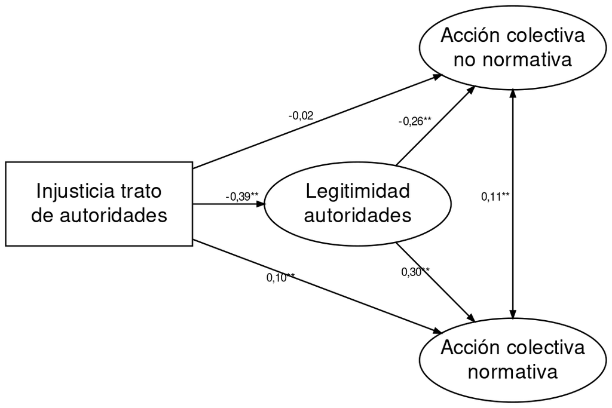

# 3 Datos ELSOC

## 3.1 Disponibilidad de mediciones por ola

En la **Tabla 1** y **Tabla 2** presentamos la disponibilidad por ola de cada una de las mediciones. En Anexos se puede encontrar el libro general de códigos y cuestionario

El color rojo indica que esta no está disponible en esa ola y verde que si está disponible en aquella ola.

**Tabla 1.** Disponibilidad de variables dependientes según año de aplicación de ELSOC

| Dimension | Pregunta | Item | 2016 | 2017 | 2018 | 2019 |
| --- | --- | --- | --- | --- | --- | --- |
| Acciones contenciosas | Durante los últimos 12 meses, con cuánta frecuencia usted ha ... | Firmado una carta o petición apoyando una causa |  |  |  |  |
| Acciones transgresoras | Durante los últimos 12 meses, con cuánta frecuencia usted ha ... | Asistido a una marcha o manifestación política |  |  |  |  |
| Acciones transgresoras | Durante los últimos 12 meses, con cuánta frecuencia usted ha ... | Participado en una huelga |  |  |  |  |
| Acciones contenciosas | Durante los últimos 12 meses, con cuánta frecuencia usted ha ... | Usado las redes sociales para expresar su opinión en temas públicos |  |  |  |  |
| Acciones contenciosas | Y, ¿en qué medida estaría usted dispuesto a participar en las siguientes acciones? | Firmar una carta o petición apoyando una causa |  |  |  |  |
| Acciones transgresoras | Y, ¿en qué medida estaría usted dispuesto a participar en las siguientes acciones? | Asistir a una marcha o manifestación política |  |  |  |  |
| Acciones transgresoras | Y, ¿en qué medida estaría usted dispuesto a participar en las siguientes acciones? | Participar en una huelga |  |  |  |  |
| Acciones contenciosas | Y, ¿en qué medida estaría usted dispuesto a participar en las siguientes acciones? | Usar las redes sociales para expresar su opinión en temas públicos |  |  |  |  |
| Acciones no normativas | ¿En qué medida cree usted que se justifican o no se justifican las siguientes situaciones? | Que un grupo de trabajadores en huelga bloquee la calle con barricadas para exigir el cumplimiento de sus derechos laborales |  |  |  |  |
| Acciones no normativas | ¿En qué medida cree usted que se justifican o no se justifican las siguientes situaciones? | Que estudiantes tiren piedras a Carabineros en una marcha por la educación del país |  |  |  |  |

**Tabla 2.** Disponibilidad de variables independientes según año de aplicación de ELSOC

| Dimension | Pregunta | Item | Ola 1 | Ola 2 | Ola 3 | Ola 4 |
| --- | --- | --- | --- | --- | --- | --- |
| Justicia trato | ¿Con cuánta frecuencia diría que personas como usted son tratadas con respeto...? | En el trabajo |  |  |  |  |
| Justicia trato | ¿Con cuánta frecuencia diría que personas como usted son tratadas con respeto...? | Por Carabineros |  |  |  |  |
| Justicia trato | ¿Con cuánta frecuencia diría que personas como usted son tratadas con respeto...? | Por personas de clase alta |  |  |  |  |
| Identidad social | En la sociedad, comúnmente, existen distintos grupos o clases sociales. Las personas de clase social alta son las que tienen los ingresos más altos, el mayor nivel de educación y los trabajos más valo… |  |  |  |  |  |
| Identidad social | Pensando en el [GRUPO O CLASE SOCIAL MENCIONADA POR EL ENCUESTADO], indíquenos su grado de acuerdo con las siguientes afirmaciones. | Me identifico con la gente de [GRUPO O CLASE SOCIAL MENCIONADA POR EL ENCUESTADO] |  |  |  |  |
| Eficacia | ¿En qué medida se encuentra usted de acuerdo o en desacuerdo con cada una de las siguientes afirmaciones? | Mi voto influye en el resultado de la elección |  |  |  |  |
| Eficacia | ¿En qué medida se encuentra usted de acuerdo o en desacuerdo con cada una de las siguientes afirmaciones? | Votar permite expresar mis ideas |  |  |  |  |
| Pertenencia a causa | Pensando en la lista de movimientos sociales que a continuación le mostraré, por favor indique ¿cuál es el que usted más valora? |  |  |  |  |  |
| Pertenencia a causa | Pensando en la lista de movimientos sociales que a continuación le mostraré, por favor indique ¿cuál es el que usted más valora? | Especifique |  |  |  |  |
| Legitimidad autoridades | A continuación, las siguientes preguntas se refieren a personas que ocupan posiciones de poder, pertenecen a la élite o ejercen algún rol de autoridad, tanto en organizaciones públicas como privadas ¿… | A estas personas no le importa lo que le pase a las personas como uno. |  |  |  |  |

[output cut: 5 more lines]

# 4 Anexos

## 4.1 Libro de códigos

**Tabla 3.** Libro de códigos para análisis de datos con ELSOC

|  | Tipo | Dimension | Concepto | Pregunta | Item | Muestra1_W01 | Muestra1_W02 | Muestra1_W03 | Muestra1_W04 | Muestra2_W01 | Muestra2_W02 | Codigo Longitudinal | Presencia |
| --- | --- | --- | --- | --- | --- | --- | --- | --- | --- | --- | --- | --- | --- |
| 1 | Dependiente | Acciones contenciosas | Participación ciudadana | Durante los últimos 12 meses, con cuánta frecuencia usted ha ... | Firmado una carta o petición apoyando una causa | c8_01 | c7_1 | c08_01 | c08_01 | c08_01 | c08_01 | c08_01 | Permanente |
| 2 | Dependiente | Acciones transgresoras | Participación ciudadana | Durante los últimos 12 meses, con cuánta frecuencia usted ha ... | Asistido a una marcha o manifestación política | c8_02 | c7_2 | c08_02 | c08_02 | c08_02 | c08_02 | c08_02 | Permanente |
| 3 | Dependiente | Acciones transgresoras | Participación ciudadana | Durante los últimos 12 meses, con cuánta frecuencia usted ha ... | Participado en una huelga | c8_03 | c7_3 | c08_03 | c08_03 | c08_03 | c08_03 | c08_03 | Permanente |
| 4 | Dependiente | Acciones contenciosas | Participación ciudadana | Durante los últimos 12 meses, con cuánta frecuencia usted ha ... | Usado las redes sociales para expresar su opinión en temas públicos | c8_04 | c7_4 | c08_04 | c08_04 | c08_04 | c08_04 | c08_04 | Permanente |
| 5 | Dependiente | Acciones contenciosas | Intención participación | Y, ¿en qué medida estaría usted dispuesto a participar en las siguientes acciones? | Firmar una carta o petición apoyando una causa | c9_01 |  | c09_01 |  | c09_01 |  | c09_01 | Intercalada |
| 6 | Dependiente | Acciones transgresoras | Intención participación | Y, ¿en qué medida estaría usted dispuesto a participar en las siguientes acciones? | Asistir a una marcha o manifestación política | c9_02 |  | c09_02 |  | c09_02 |  | c09_02 | Intercalada |
| 7 | Dependiente | Acciones transgresoras | Intención participación | Y, ¿en qué medida estaría usted dispuesto a participar en las siguientes acciones? | Participar en una huelga | c9_03 |  | c09_03 |  | c09_03 |  | c09_03 | Intercalada |
| 8 | Dependiente | Acciones contenciosas | Intención participación | Y, ¿en qué medida estaría usted dispuesto a participar en las siguientes acciones? | Usar las redes sociales para expresar su opinión en temas públicos | c9_04 |  | c09_04 |  | c09_04 |  | c09_04 | Intercalada |
| 9 | Exógena | Justicia trato | Percepción Trato Justo | ¿Con cuánta frecuencia diría que personas como usted son tratadas con respeto...? | En el trabajo | c35_02 |  | c35_02 |  | c35_02 | c35_02 | c35_02 | Intercalada |
| 10 | Exógena | Justicia trato | Percepción Trato Justo | ¿Con cuánta frecuencia diría que personas como usted son tratadas con respeto...? | Por Carabineros | c35_03 |  | c35_03 |  | c35_03 | c35_03 | c35_03 | Intercalada |

[output cut: 15 more lines]

## 4.2 Cuestionario

1. **Preguntas permanentes**
- **Acciones contenciosas** (normativas)
  - Participación ciudadana: “Durante los últimos 12 meses, con cuánta frecuencia usted ha …”
    1. Firmado una carta o petición apoyando una causa
    2. Usado las redes sociales para expresar su opinión en temas públicos
- **Acciones transgresoras** (no-normativas)
  - Participación ciudadana: “Durante los últimos 12 meses, con cuánta frecuencia usted ha …”
    1. Asistido a una marcha o manifestación política
    2. Participado en una huelga
  - Justificación Violencia: ¿En qué medida cree usted que se justifican o no se justifican las siguientes situaciones?
    1. Que un grupo de trabajadores en huelga bloquee la calle con barricadas para exigir el cumplimiento de sus derechos laborales
    2. Que estudiantes tiren piedras a Carabineros en una marcha por la educación del país
- **Identidad social**
  - Identidad de clase: En la sociedad, comúnmente, existen distintos grupos o clases sociales. Las personas de clase social alta son las que tienen los ingresos más altos, el mayor nivel de educación y los trabajos más valorados. Las personas de clase social baja son las que tienen los ingresos más bajos, el menor nivel de educación y los trabajos menos valorados. Entre estas clases existen otras intermedias. Según su opinión, a cuál de los siguientes grupos o clases sociales pertenece usted (Leer todas las categorías):
- **Eficacia**
  - Autoeficacia política: ¿En qué medida se encuentra usted de acuerdo o en desacuerdo con cada una de las siguientes afirmaciones?
    1. Mi voto influye en el resultado de la elección
    2. Votar permite expresar mis ideas
- **Pertenencia a causa**
  - Movimientos sociales: Pensando en la lista de movimientos sociales que a continuación le mostraré, por favor indique ¿cuál es el que usted más valora?
- **Justicia Distributiva**
  - ¿Cuánto cree que sería una remuneración justa para usted? (Considere el ingreso líquido, es decir, después de descuentos de impuestos, salud, previsión u otros)
  - ¿Qué tan insatisfecho o satisfecho está usted con su ingreso hoy en día? En una escala de 1 a 5, donde 1 es totalmente insatisfecho, y 5 es totalmente satisfecho.
2. **Preguntas intercaladas**

Las variables que podrían aproximarse a **Legitimidad autoridades**, **Justicia en el trato** y **Disposición a participar** están para al menos 2 olas y para las mismas (ola1 y ola3)

- **Justicia en trato**
  - Perceción Trato Justo: ¿Con cuánta frecuencia diría que personas como usted son tratadas con respeto…?"
    1. En el trabajo
    2. Por Carabineros
    3. Por personas de clase alta